Assignment 2: k-means and k-NN

This is well known dataset found in the pattern recognition literature. Fisher’s paper is a classic in the field and is referenced frequently to this day. The data set contains 3 classes of 50 instances each, where each class refers to the type of iris plant.

Predicted attribute: class of iris plant.

Attribute Information:  
* sepal length in cm  
* sepal width in cm  
* petal length in cm  
* petal width in cm  
* Iris species: Setosa; Versicolour; Virginica

1 Compute summary statistics and plot a scatterplot matrix for each of the three iris species. `Species` is a factor and the other variables are numberic.

```r
data(iris)
attach(iris)
head(iris)
```

```
##   Sepal.Length Sepal.Width Petal.Length Petal.Width Species
## 1          5.1         3.5          1.4         0.2  setosa
## 2          4.9         3.0          1.4         0.2  setosa
## 3          4.7         3.2          1.3         0.2  setosa
## 4          4.6         3.1          1.5         0.2  setosa
## 5          5.0         3.6          1.4         0.2  setosa
## 6          5.4         3.9          1.7         0.4  setosa
```

```r
# Put your R code here.
summary(iris[iris$Species=="setosa",]) #summary(iris[which(iris$Species=="setosa"),])
```

```
##   Sepal.Length    Sepal.Width     Petal.Length    Petal.Width
##  Min.   :4.300   Min.   :2.300   Min.   :1.000   Min.   :0.100
##  1st Qu.:4.800   1st Qu.:3.200   1st Qu.:1.400   1st Qu.:0.200
##  Median :5.000   Median :3.400   Median :1.500   Median :0.200
##  Mean   :5.006   Mean   :3.428   Mean   :1.462   Mean   :0.246
##  3rd Qu.:5.200   3rd Qu.:3.675   3rd Qu.:1.575   3rd Qu.:0.300
##  Max.   :5.800   Max.   :4.400   Max.   :1.900   Max.   :0.600
##        Species
##  setosa    :50
##  versicolor: 0
##  virginica : 0
##
##
##
```

```r
summary(iris[iris$Species=="versicolor",])
```

```
##   Sepal.Length    Sepal.Width     Petal.Length   Petal.Width
##  Min.   :4.900   Min.   :2.000   Min.   :3.00   Min.   :1.000
##  1st Qu.:5.600   1st Qu.:2.525   1st Qu.:4.00   1st Qu.:1.200
##  Median :5.900   Median :2.800   Median :4.35   Median :1.300
##  Mean   :5.936   Mean   :2.770   Mean   :4.26   Mean   :1.326
##  3rd Qu.:6.300   3rd Qu.:3.000   3rd Qu.:4.60   3rd Qu.:1.500
##  Max.   :7.000   Max.   :3.400   Max.   :5.10   Max.   :1.800
##        Species
##  setosa    : 0
##  versicolor:50
##  virginica : 0
##
##
##
```

```r
summary(iris[iris$Species=="virginica",])
```

```
##   Sepal.Length    Sepal.Width     Petal.Length    Petal.Width
##  Min.   :4.900   Min.   :2.200   Min.   :4.500   Min.   :1.400
##  1st Qu.:6.225   1st Qu.:2.800   1st Qu.:5.100   1st Qu.:1.800
##  Median :6.500   Median :3.000   Median :5.550   Median :2.000
##  Mean   :6.588   Mean   :2.974   Mean   :5.552   Mean   :2.026
##  3rd Qu.:6.900   3rd Qu.:3.175   3rd Qu.:5.875   3rd Qu.:2.300
##  Max.   :7.900   Max.   :3.800   Max.   :6.900   Max.   :2.500
##        Species
##  setosa    : 0
##  versicolor: 0
##  virginica :50
##
##
##
```

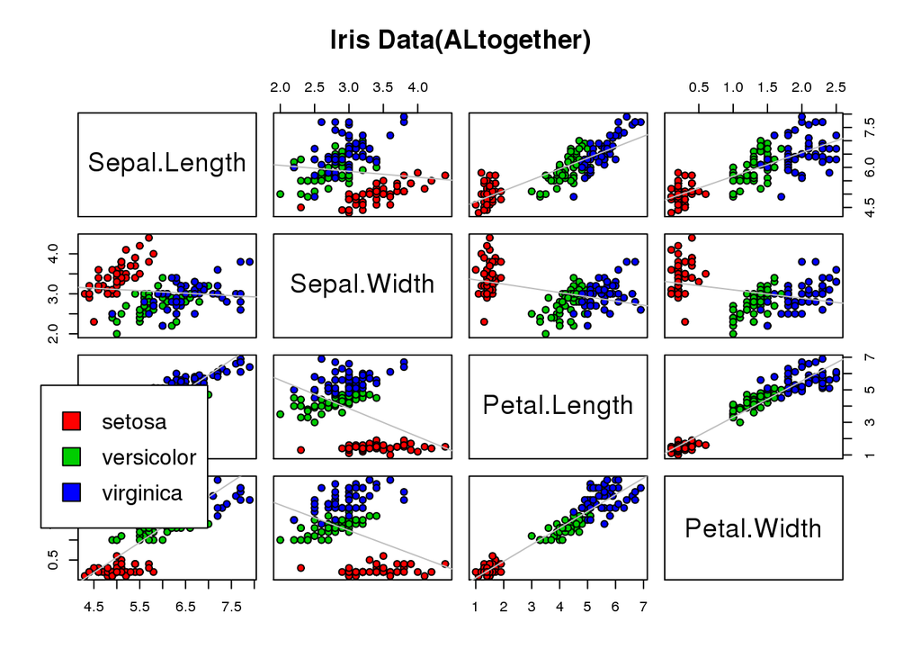

```r
pairs(iris[1:4], main = "Iris Data(ALtogether)", pch = 21, bg = c("red", "green3", "blue")[unclass(iris$Species)],panel = function (x, y, ...) {
    points(x, y, ...)
    abline(lm(y ~ x), col = "grey")
    });  par(xpd=TRUE);   legend(0,.4 , as.vector(unique(iris$Species)), fill=c("red", "green3", "blue"))
```

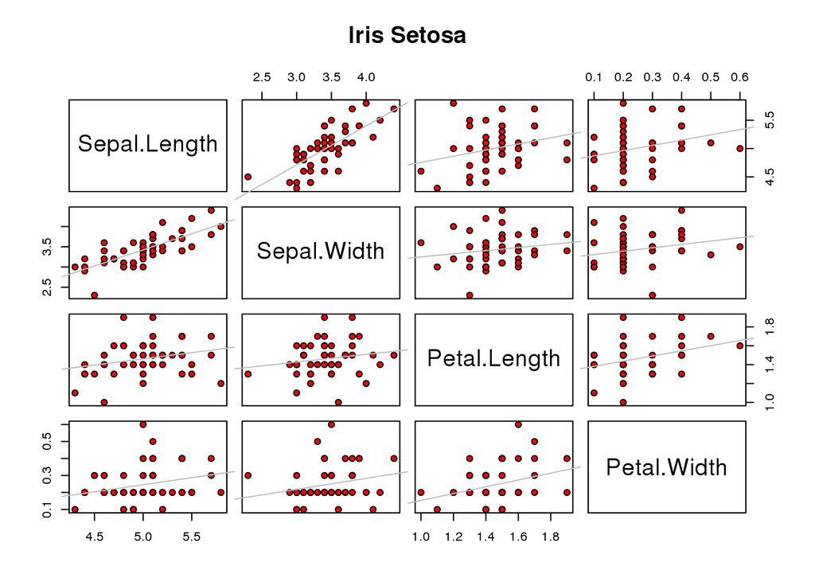

```r
irisSetosa <- iris[iris$Species=="setosa",]
irisSetosa$Species <- NULL
pairs(irisSetosa[1:4], main = "Iris Setosa", pch = 21, bg = c("red"),panel = function (x, y, ...) {
    points(x, y, ...)
    abline(lm(y ~ x), col = "grey")
    })
```

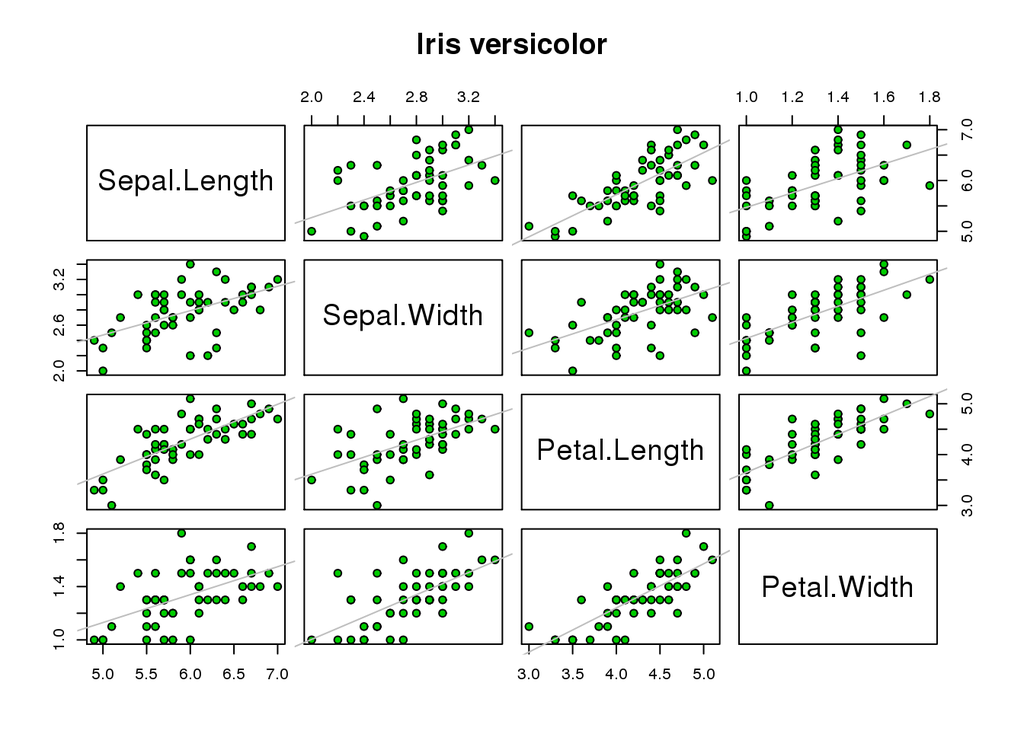

```r
irisVersi <- iris[iris$Species=="versicolor",]
irisVersi$Species <- NULL
pairs(irisVersi[1:4], main = "Iris versicolor", pch = 21, bg = c("green3"),panel = function (x, y, ...) {
    points(x, y, ...)
    abline(lm(y ~ x), col = "grey")
    })
```

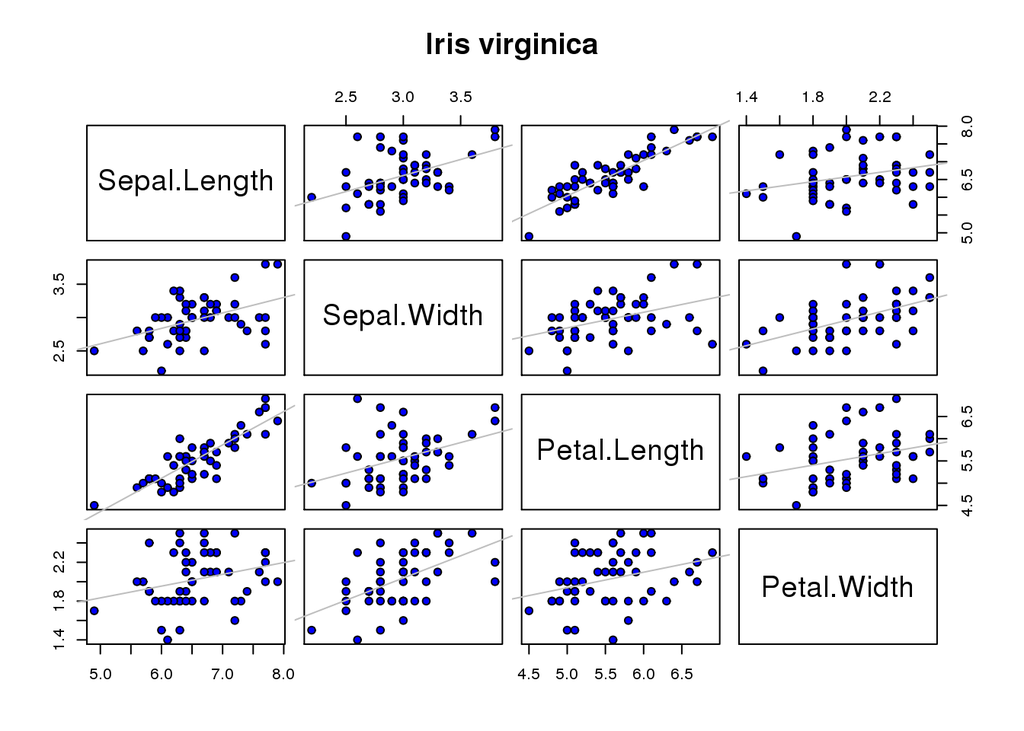

```r
irisVirginica <- iris[iris$Species=="virginica",]
irisVirginica $Species <- NULL
pairs(irisVirginica [1:4], main = "Iris virginica", pch = 21, bg = c("blue"),panel = function (x, y, ...) {
    points(x, y, ...)
    abline(lm(y ~ x), col = "grey")
    })
```

2 Create a logical variable `train` and add this to the `iris` data frame. Randomly sample 35 observations from each of the species and label these `TRUE`. Label the remaining 15 in each group (species) `FALSE`. The training and test observations should remain fixed for the remainder of the analysis. For convenience subset the sample into training and testing data frames.

```r
# Put your R code here.
train1 <- sample(1:50, 35, replace=FALSE)
train2 <- sample(51:100, 35, replace=FALSE)
train3 <- sample(101:150, 35, replace=FALSE)

test1 <- setdiff(1:50, train1)
test2 <- setdiff(51:100, train2)
test3 <- setdiff(101:150, train3)


train11 <- iris[train1,] # or train12 <- subset(iris[train1, ])
train11$train <- rep.int(TRUE,35)
test11 <- iris[test1,]
test11$train <-rep.int(FALSE,15)
setosa <- rbind(train11,test11)

train22 <- iris[train2,] # or train12 <- subset(iris[train1, ])
train22$train <- rep.int(TRUE,35)
test22 <- iris[test2,]
test22$train <-rep.int(FALSE,15)
versicolor <- rbind(train22,test22)

train33 <- iris[train3,] # or train12 <- subset(iris[train1, ])
train33$train <- rep.int(TRUE,35)
test33 <- iris[test3,]
test33$train <-rep.int(FALSE,15)
virginica <- rbind(train33,test33)

traina <- rbind(train11,train22,train33); head(traina)
```

```
##    Sepal.Length Sepal.Width Petal.Length Petal.Width Species train
## 18          5.1         3.5          1.4         0.3  setosa  TRUE
## 33          5.2         4.1          1.5         0.1  setosa  TRUE
## 8           5.0         3.4          1.5         0.2  setosa  TRUE
## 40          5.1         3.4          1.5         0.2  setosa  TRUE
## 16          5.7         4.4          1.5         0.4  setosa  TRUE
## 1           5.1         3.5          1.4         0.2  setosa  TRUE
```

```r
testa <- rbind(test11,test22,test33) ; head(testa)
```

```
##    Sepal.Length Sepal.Width Petal.Length Petal.Width Species train
## 4           4.6         3.1          1.5         0.2  setosa FALSE
## 6           5.4         3.9          1.7         0.4  setosa FALSE
## 11          5.4         3.7          1.5         0.2  setosa FALSE
## 12          4.8         3.4          1.6         0.2  setosa FALSE
## 14          4.3         3.0          1.1         0.1  setosa FALSE
## 17          5.4         3.9          1.3         0.4  setosa FALSE
```

```r
true.labelsa <- testa$Species
```

3 Perform an average linkage hierarchical cluster analysis on the training data frame without consideration of the species groupings and cut the tree at 3 groups. Provide relevant graphical and numerical summeries.

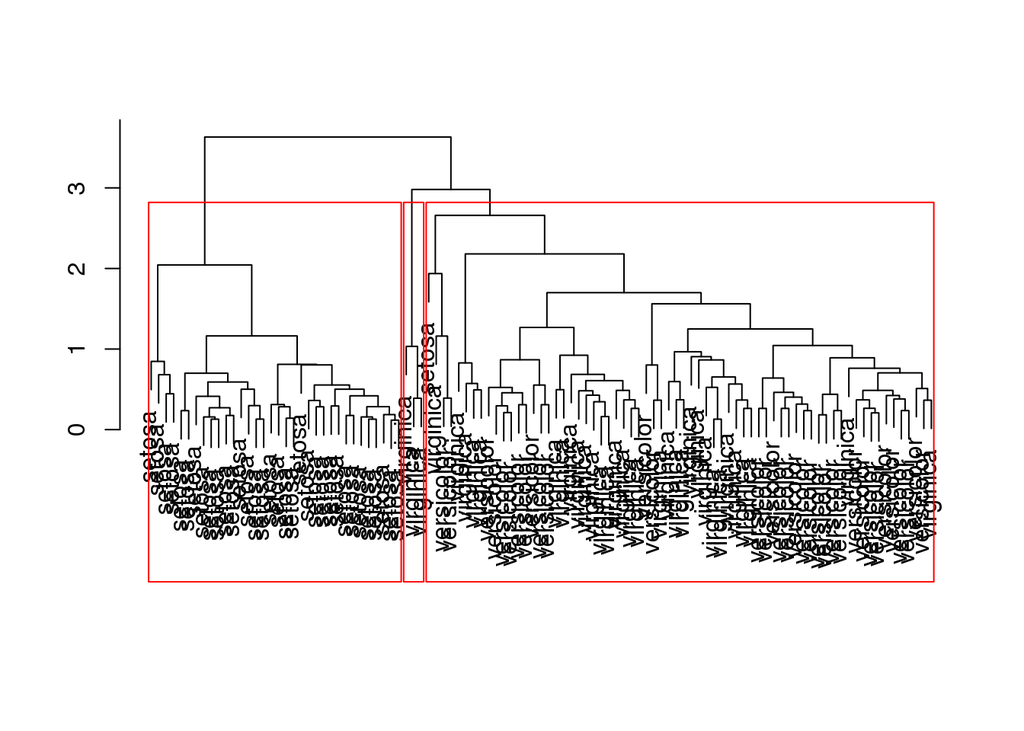

```r
# Put your R code here.
traind <- traina
traind$Species <- NULL
traind$train <- NULL
traina.sc <- scale(traind)
traina.dis <- dist(traina.sc)
h.averagea <- hclust(traina.dis, method="average")
plot(h.averagea, ann = F , labels = traina$Species )
rect.hclust(h.averagea, k=3)
```

```r
cutree(h.averagea, 3)
```

```
##  18  33   8  40  16   1  15  41  32  22   7  13  45   3  39  35   5  38
##   1   1   1   1   1   1   1   1   1   1   1   1   1   1   1   1   1   1
##  20  43  34  42  10  24  37  48  31  21  23   2  47  29   9  27  36  66
##   1   1   1   2   1   1   1   1   1   1   1   1   1   1   1   1   1   2
##  95  87  55  75  83  92  52  74 100  70  98  93  91  63  77  58  64  57
##   2   2   2   2   2   2   2   2   2   2   2   2   2   2   2   2   2   2
##  96  67  53  62  79  68  69  89  51  85  99  81  78  86  72  76 135 127
##   2   2   2   2   2   2   2   2   2   2   2   2   2   2   2   2   2   2
## 144 132 111 134 109 145 123 101 129 143 139 120 131 104 133 124 118 121
##   2   3   2   2   2   2   2   2   2   2   2   2   2   2   2   2   3   2
## 103 106 140 149 141 112 113 122 147 142 107 119 125 110 114
##   2   2   2   2   2   2   2   2   2   2   2   2   2   3   2
```

```r
initial.pointsa <- tapply(traina.sc, list(rep(cutree(h.averagea, 3), ncol(traina.sc)), col(traina.sc)), mean)
dimnames(initial.pointsa) <- list(NULL, dimnames(traina.sc)[[2]])
initial.pointsa
```

```
##      Sepal.Length Sepal.Width Petal.Length Petal.Width
## [1,]   -1.0241982   0.8850610   -1.3024903  -1.2581118
## [2,]    0.4224379  -0.5090111    0.5866571   0.5698749
## [3,]    2.0323200   1.5068934    1.4639955   1.3414360
```

4 Cluster the training data using the $k$-means algorithm for $k=3$ groups using the hierarchical cluster results above for the seed points. Provide PCA summaries of the results. Discuss the agreement between the true groups and the groups found by the $k$-means algorithm.

```r
# Put your R code here.
trainb.sc <- traina.sc
initial.pointsb <- initial.pointsa
kmeansa <- kmeans(trainb.sc,initial.pointsb)
kmeansa$centers
```

```
##   Sepal.Length Sepal.Width Petal.Length Petal.Width
## 1  -1.04146557   0.8090557   -1.3046924  -1.2558125
## 2   0.05131411  -0.8363149    0.3962665   0.3110059
## 3   1.14662435   0.1711883    0.9937858   1.0504400
```

```r
kmeansa$cluster  # the clusters found by k-means are NOT identical to those found by cutting the average-linkage tree into three grpups.
```

```
##  18  33   8  40  16   1  15  41  32  22   7  13  45   3  39  35   5  38
##   1   1   1   1   1   1   1   1   1   1   1   1   1   1   1   1   1   1
##  20  43  34  42  10  24  37  48  31  21  23   2  47  29   9  27  36  66
##   1   1   1   1   1   1   1   1   1   1   1   1   1   1   1   1   1   3
##  95  87  55  75  83  92  52  74 100  70  98  93  91  63  77  58  64  57
##   2   3   2   2   2   2   3   2   2   2   2   2   2   2   2   2   2   3
##  96  67  53  62  79  68  69  89  51  85  99  81  78  86  72  76 135 127
##   2   2   3   2   2   2   2   2   3   2   2   2   3   3   2   2   2   2
## 144 132 111 134 109 145 123 101 129 143 139 120 131 104 133 124 118 121
##   3   3   3   2   2   3   3   3   3   2   2   2   3   3   3   2   3   3
## 103 106 140 149 141 112 113 122 147 142 107 119 125 110 114
##   3   3   3   3   3   2   3   2   2   3   2   3   3   3   2
```

```r
table(kmeansa$cluster,as.numeric(traina$Species))
```

```
##
##      1  2  3
##   1 35  0  0
##   2  0 27 13
##   3  0  8 22
```

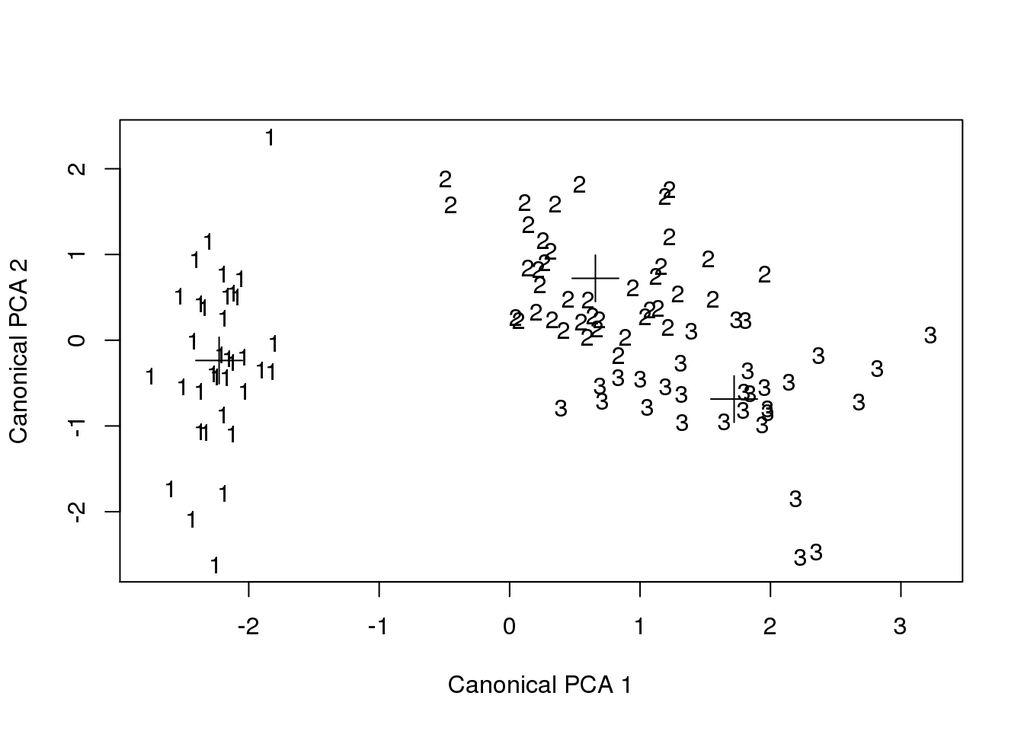

```r
# for group 2 and 3 it is not good but for group one it is perfect

kmeans.pca <- princomp(trainb.sc)
kmeans.pca.pred <- predict(kmeans.pca)
kmeans.pca.centers <- predict(kmeans.pca, kmeansa$centers)
plot(kmeans.pca.pred[, 1:2], type="n", xlab = "Canonical PCA 1", ylab = "Canonical PCA 2")
text(kmeans.pca.pred[, 1:2], labels = kmeansa$cluster)
points(kmeans.pca.centers[, 1:2], pch = 3, cex = 3)
```

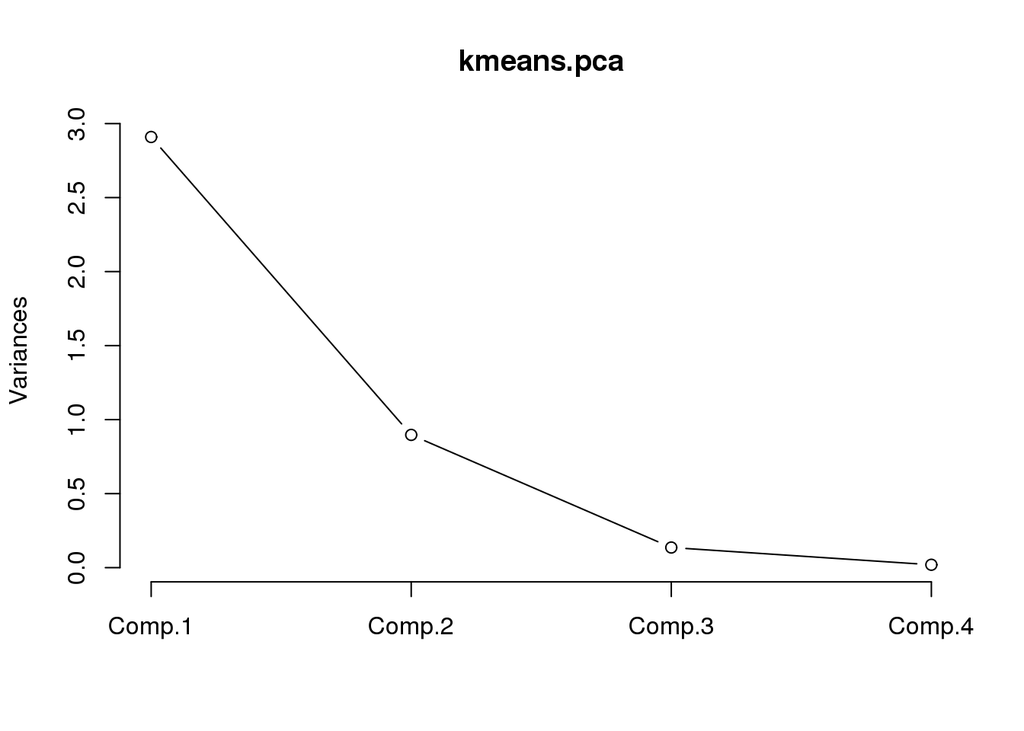

```r
screeplot(kmeans.pca, type = "lines")
```

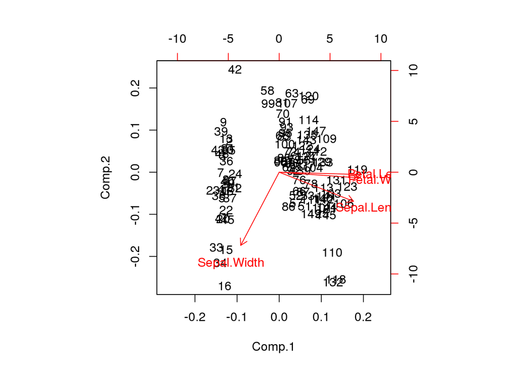

```r
biplot(kmeans.pca, pc.biplot = FALSE)
```

5 Perform a $k$-NN classification using $k = 2$ nearest neighbors for the three groups. Compute and discuss the confusion matrix based on the test data frame.

```r
# Put your R code here.
library(class)
trainb <- traina
trainb$Species <- NULL ; trainb$train <- NULL
testb <- testa
testb$Species <- NULL ; testb$train<- NULL
(diabetes.knn <- knn (trainb, testb, traina$Species, k=2)) ;
```

```
##  [1] setosa     setosa     setosa     setosa     setosa     setosa
##  [7] setosa     setosa     setosa     setosa     setosa     setosa
## [13] setosa     setosa     setosa     versicolor versicolor versicolor
## [19] versicolor versicolor versicolor virginica  virginica  versicolor
## [25] versicolor virginica  versicolor versicolor versicolor versicolor
## [31] virginica  virginica  virginica  virginica  virginica  virginica
## [37] virginica  virginica  virginica  virginica  virginica  virginica
## [43] virginica  virginica  virginica
## Levels: setosa versicolor virginica
```

```r
table(diabetes.knn,true.labelsa)
```

```
##             true.labelsa
## diabetes.knn setosa versicolor virginica
##   setosa         15          0         0
##   versicolor      0         12         0
##   virginica       0          3        15
```

6 Determine the optimal $k$, i.e., the number of nearest neighbors, for the three-group problem using the confusion matrix computed on the test data frame in each case. Discuss.

```r
# Put your R code here.
ratea <- c()
n.testa <- length(testa[,1])

for (k in 1:20) {
  predicted.labelsa <- knn(trainb, testb, traina$Species, k)
  n.incorrect.labelsa <- sum(predicted.labelsa != true.labelsa)
  misclassification.ratea <- n.incorrect.labelsa / n.testa
  ratea <- c(misclassification.ratea, ratea)

}
ratea
```

```
##  [1] 0.04444444 0.02222222 0.02222222 0.04444444 0.02222222 0.02222222
##  [7] 0.02222222 0.02222222 0.02222222 0.04444444 0.04444444 0.04444444
## [13] 0.04444444 0.04444444 0.04444444 0.04444444 0.06666667 0.04444444
## [19] 0.04444444 0.06666667
```

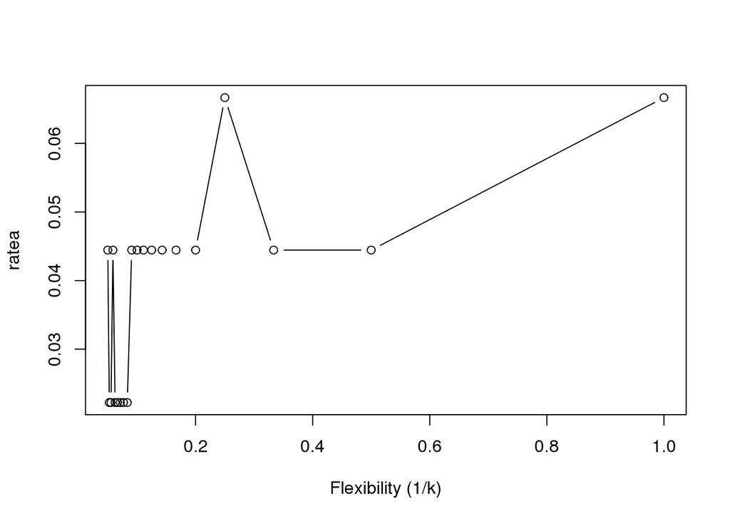

```r
plot(1/(20:1), ratea, type="b", xlab="Flexibility (1/k)")
```

```r
#According to the figure the optimal points easily can be chosen by looking at the figure (it is different for each run because the samples are random)
```